# Brand Clothing Sizing Blog Draft

Mia Rivera

3/6/2020

## Brand Sizing VS. Population Measurements

The fashion industry has embraced data science in order to increase business, for example through predicting customer style preferences or by predicting upcoming trends. While businesses have been experiencing these advantages, the average customer hasn’t been able to improve their purchasing decisions based on large data analysis. Consumers increasingly do their shopping online, but online clothing shopping still remains difficult due to uncertainty in fit and sizing across brands and items.

Typically, brands provide sizing charts on their retail website for customers to reference in order to assist with their online purchasing decisions. Depending on the clothing item, different body measurements are used to determine a person’s clothing size. When purchasing tops, most brands will use a chest(or bust) measurement along with one or two other body measurements depending on whether the sizing chart is for men or women. Most women’s sizing charts for tops use the bust and waist measurements, and occasionally an arm measurement for determining size. In men’s sizing charts for tops, the chest, neck, and arm measurements are the standard for determining size. In this article, we will determine which brands have sizing most representative of the U.S. population.

In order to have a standard to compare sizing against, body measurement data was taken from the 2012 US Army Anthropometric Survey (ANSUR-II) and the 2017-2018 CDC National Health and Nutrition Examination Survey (NHANES).

Unfortunately, the NHANES dataset does not include chest measurements, but we can still compare the measurements between the demographics of the two datasets using waist measurements.

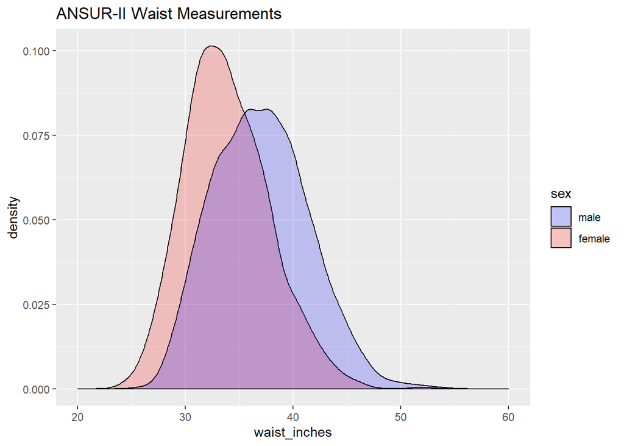

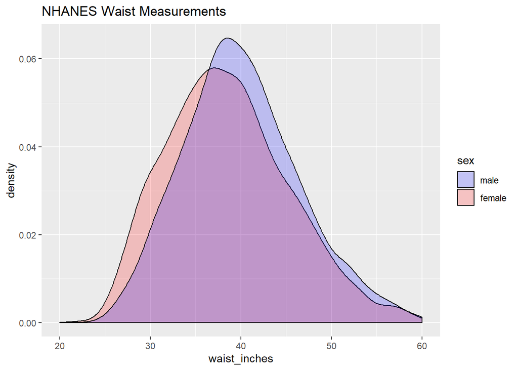

As we might have guessed, the data shows that the individuals in the US Army for the ANSUR-II data are leaner than the general populace measured for NHANES. We can corroborate this by performing a t-test on the mean of the waist measurements between the two data sets.

```
##
##  Welch Two Sample t-test
##
## data:  nhanes_female$waist_inches and ansur_female$waist_inches
## t = 30.048, df = 4345.2, p-value < 2.2e-16
## alternative hypothesis: true difference in means is not equal to 0
## 95 percent confidence interval:
##  4.516794 5.147331
## sample estimates:
## mean of x mean of y
##  38.72597  33.89391
```

```
##
##  Welch Two Sample t-test
##
## data:  nhanes_male$waist_inches and ansur_male$waist_inches
## t = 21.345, df = 3958.1, p-value < 2.2e-16
## alternative hypothesis: true difference in means is not equal to 0
## 95 percent confidence interval:
##  2.854776 3.432255
## sample estimates:
## mean of x mean of y
##  40.17412  37.03061
```

The results of the t-tests show that there is a statistically significant difference in means for both men’s and women’s measurements, with t=30.048 and t=21.345 with p-value<2.2e-16 respectively. From the t-test we also know that there is a larger difference in means in the female measurements than the males.

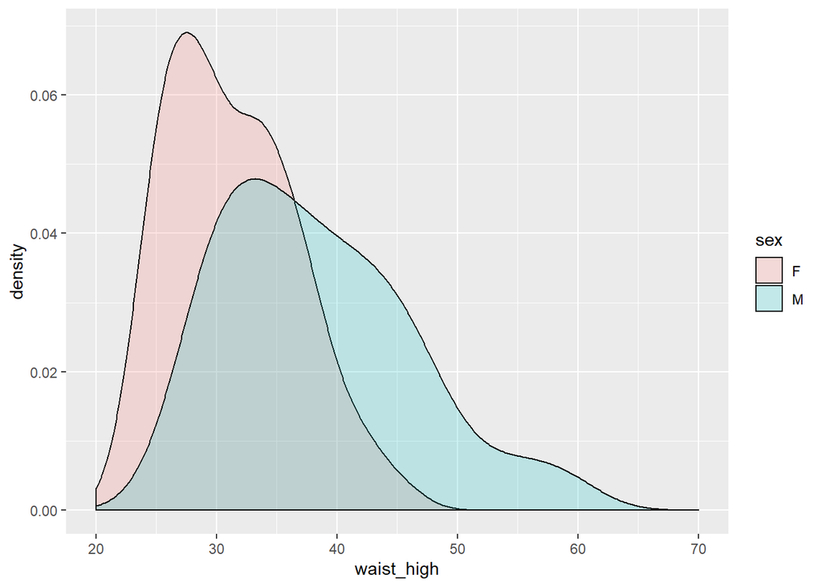

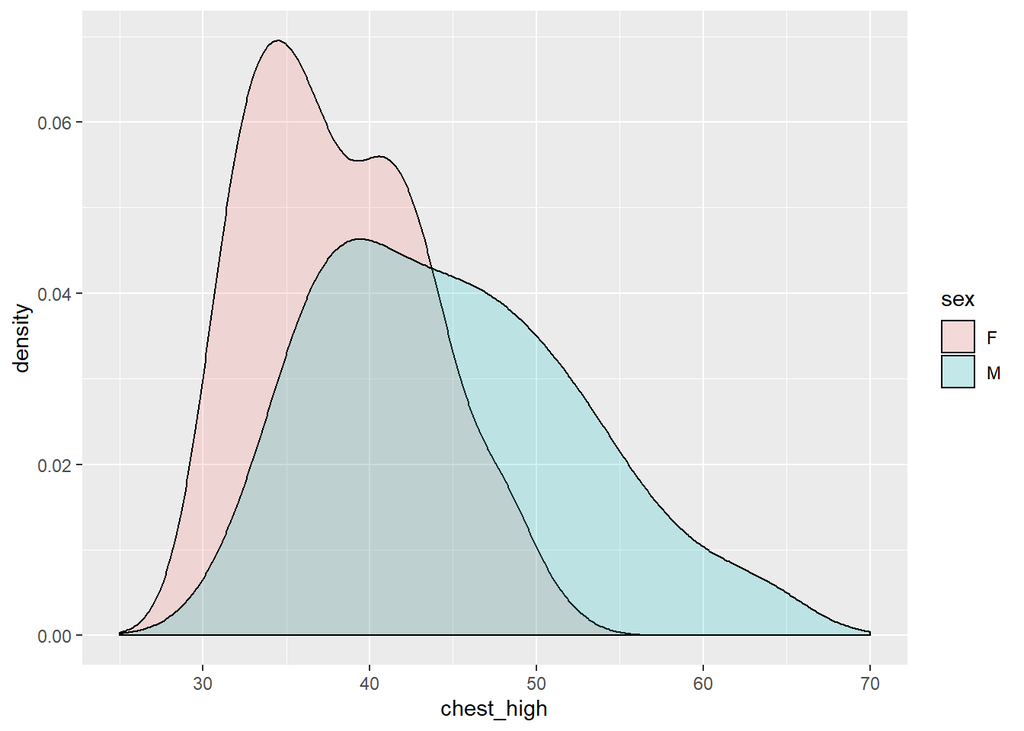

From doing a density plot on the upper value of the waist measurements used by the 13 clothing brands sampled, we can see that the distributions do not closely reflect the density plots of the population measurements, although it does come closer to the density plot of ANSUR-II.

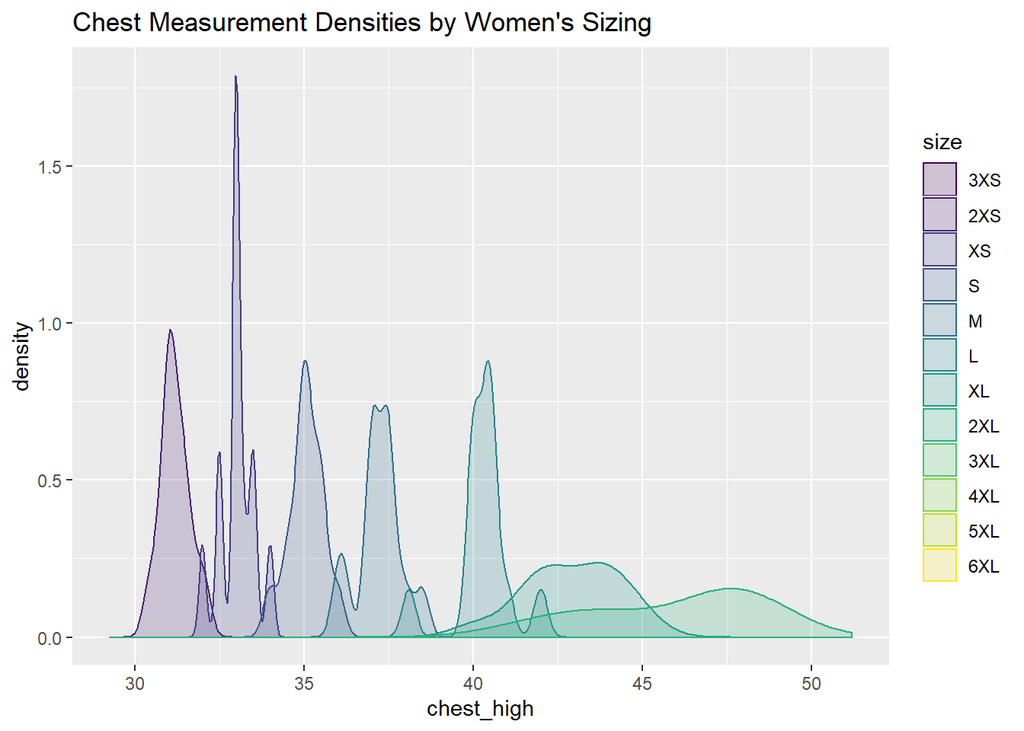

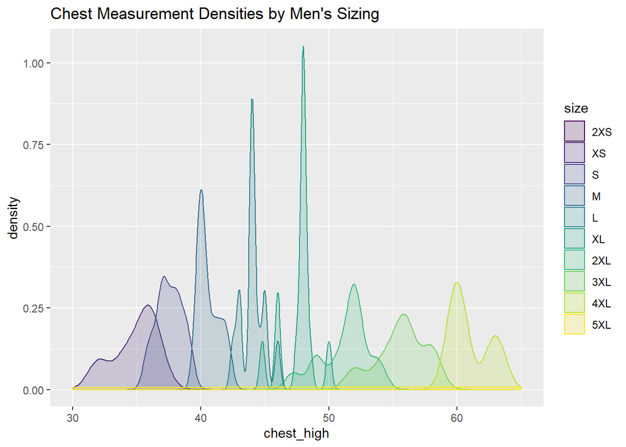

If we overlay the density measurement for each brand over the population measurement, we can see which brand’s sizings/measurements density best correlate to population measurement density.

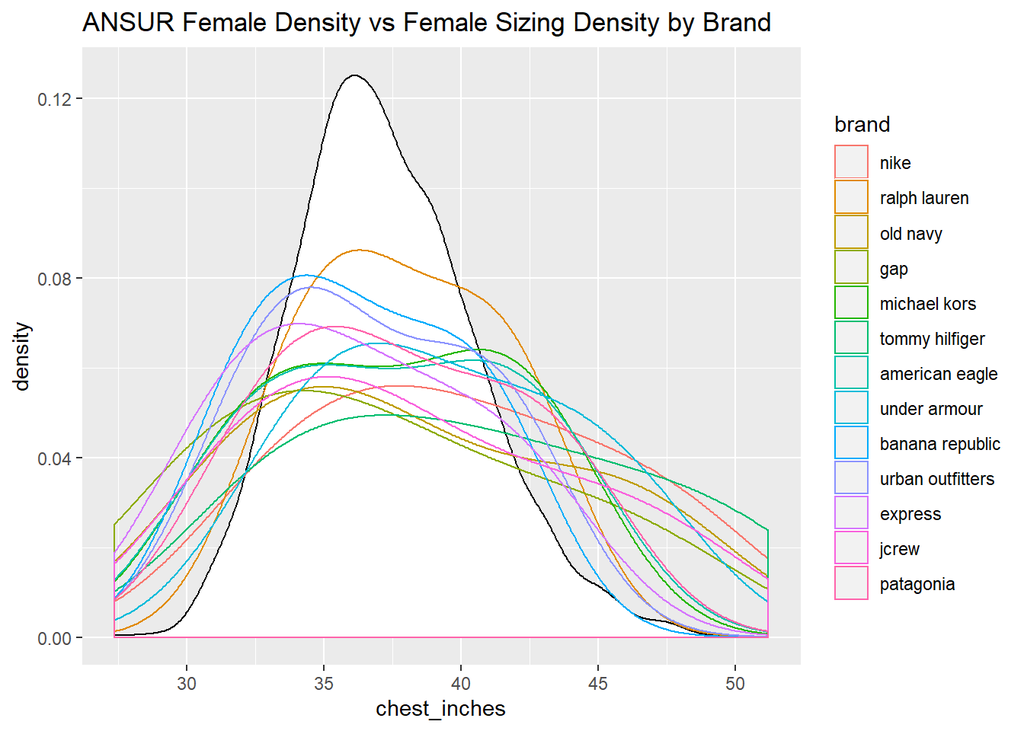

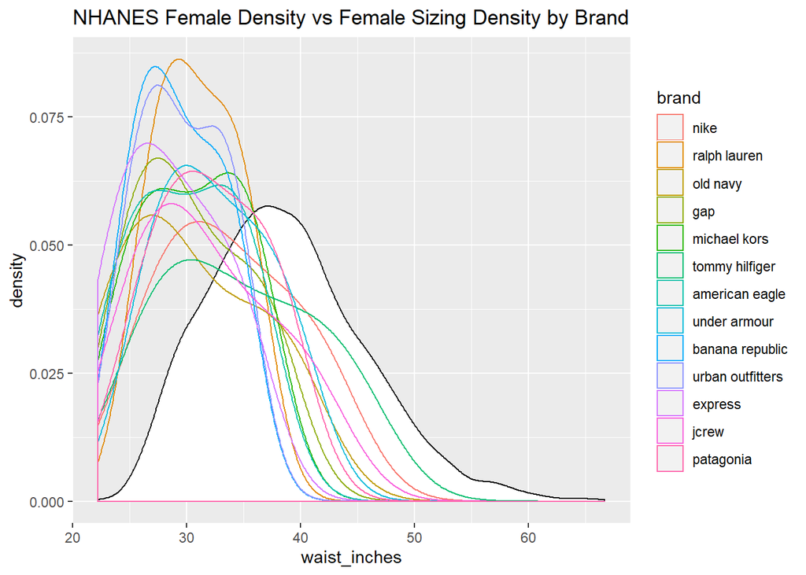

For females, we can see that when comparing the brands to the ANSUR female measurements, the densities mostly overlap over the same areas. Most brands seem to lean towards a smaller mean density compared to the ANSUR female demographic, but it appears that Ralph Lauren followed by Banana Republic and Urban Outfitters are most closely matching the ANSUR demographic. However, since all of the brands contain the measurement range of the ANSUR female demographic, there would be little impact in knowing which of the brands best fit the demographic measurement density. Looking at the brands compared to the NHANES demographic (using waist measurements since NHANES doesn’t record chest measurements), we see that for what we may consider a more “typical” American demographic we have much less correlation between the brands and demographic densities. Since the measurements from the NHANES data set tend to be larger, there is much less overlap between the brand densities and the demographic density. Tommy Hilfiger, Nike, and J.Crew would be able to have sizings to fit the majority of the NHANES female population.

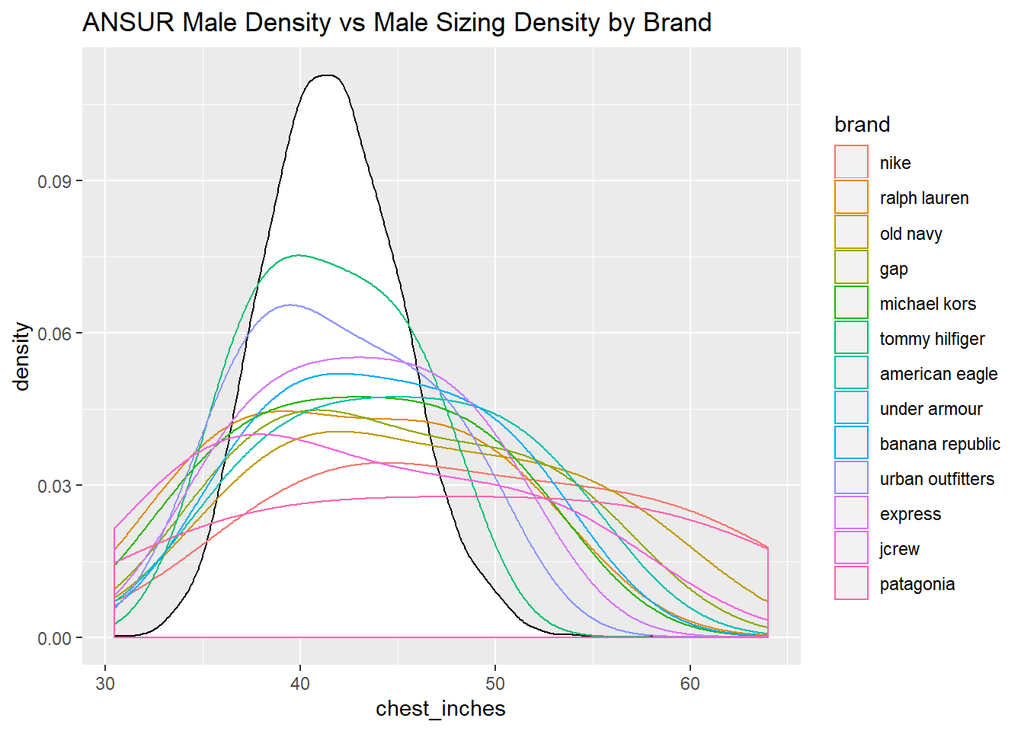

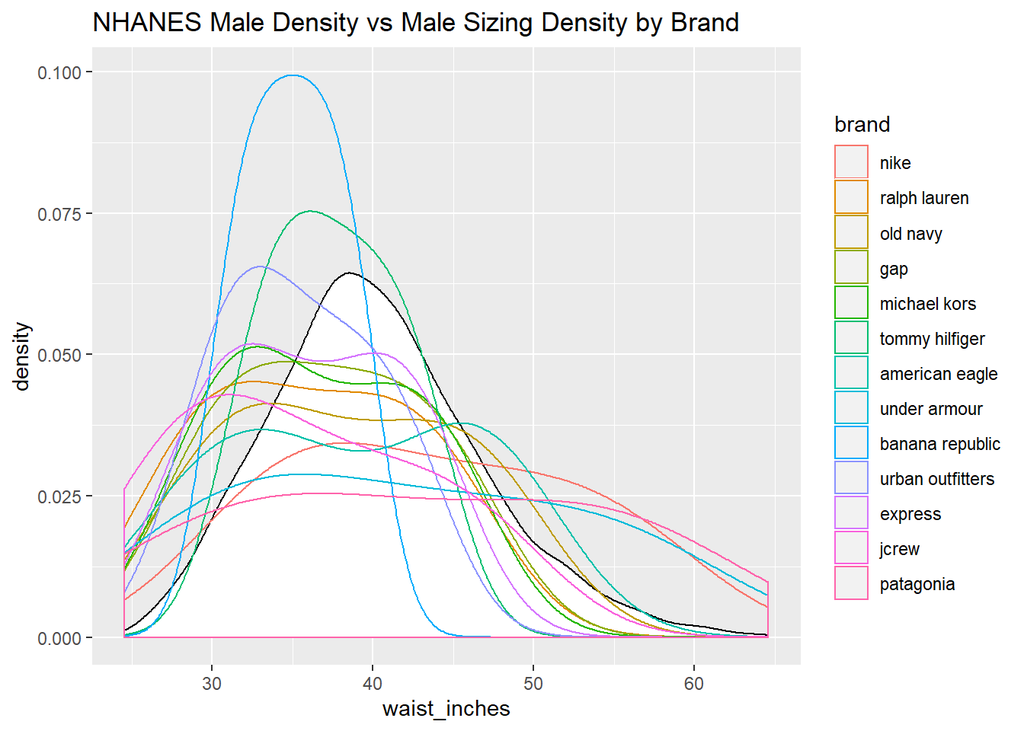

We can apply the same methods from above to find which brands best match the men in our data sets. When finding the best density match for the ANSUR men, Tommy Hilfiger is the closest and is followed by Urban Outfitters. Tommy Hilfiger is still a good brand for the NHANES men demographic, but Urban Outfitters is not as well matched as it was with the ANSUR population.

# References

http://mreed.umtri.umich.edu/mreed/downloads.html#ansur2 https://wwwn.cdc.gov/nchs/nhanes/continuousnhanes/default.aspx?BeginYear=2017 https://www.underarmour.com/en-us/size-charts https://www.ae.com/us/en/content/help/men-size-chart https://www.ae.com/us/en/content/help/women-size-chart https://usa.tommy.com/en/customerservice/size-guide https://bananarepublic.gap.com/customerService/info.do?cid=80743&cs=size_charts https://www.gap.com/browse/sizeChart.do?cid=2082 https://www.gap.com/browse/sizeChart.do?cid=2082 https://oldnavy.gap.com/browse/sizeChart.do?cid=3102 https://oldnavy.gap.com/browse/sizeChart.do?cid=3102 https://www.ralphlauren.com/size-guide/size-guide.html https://www.nike.com/us/en_us/sfg/mens-tops-sizing-chart https://www.nike.com/us/en_us/sfg/womens-tops-sizing-chart https://www.landsend.com/customer-service/size-charts/ https://www.patagonia.com/ https://www.urbanoutfitters.com/help/size-charts https://www.jcrew.com/r/size-charts